# Complexity of US Baby Names

Jaylin Lowe, Xinhe Wu, and Yiheng Xiang

# Introduction

Every year, names US parents choose for their children seem to get more unusual and more complex. The decision of what to name your baby has become so complex that some people choose to hire naming consultants to help them find unique names<sup>[1]</sup>. However, this phenomenon is mostly ancedotal and may be influenced by the number of celebrities choosing extremely unusual and complicated names for this children. In this project, we set out to explore how the complexity of US baby names has changed over time. Are names actually becoming more complex? Are we able to model how aspects of names change over time?

To answer these questions, we created three different time series, separated by gender, using data from the US Social Security Administration on first names given to babies born between 1880 and 2017<sup>[2]</sup>. Names given to fewer than five babies of the same gender in the same year are excluded; all others are included. As a result, we cannot observe trends in extremely unusual names; however, we can still observe general naming trends. The dataset gives us the number of babies given a particular name, divided by gender and year.

For each year and sex, we calculated three values aimed at capturing the complexity of names. These three were: the average length of a name, the average number of vowels in a name, and the average longest run of consonants in a name. These were weighted by how popular a name was. In other words, the denominator for these averages was the number of people born that year, not the number of unique names given. Popular names will be given more weight than unusual names. The first two values are fairly self-explanatory, but the third may benefit from an example. For each name, we calculated the longest run of consonants in a name. For example, the name “Isabella” has a longest consonant run of 2, from the “ll” part. The names “Ava” and “Astrid” would have a longest consonant run of 1 and 3, respectively.

We chose these questions because they seemed to address the question of “complexity” while being fairly easy to calculate and intuitive to explain. “Complexity” can mean very different things when it comes to names. We would generally consider very long names to be complex, but short names with a lot of consonants in a row might also fall under “complex names” especially if the repeated consonants make the name hard to pronounce. We initially got the idea to do average length and average vowel count from a data visualization we found<sup>[3]</sup> and came up with the idea for longest consonant run on our own.

We primarily focus on modeling these time series properly, with a slight focus on forecasting what these trends might look like in the next few years.

# Exploratory Data Analysis

We start by exploring what these time series look like visually. First, we plot the average length of the names of all babies born 1880-2017, separated by sex.

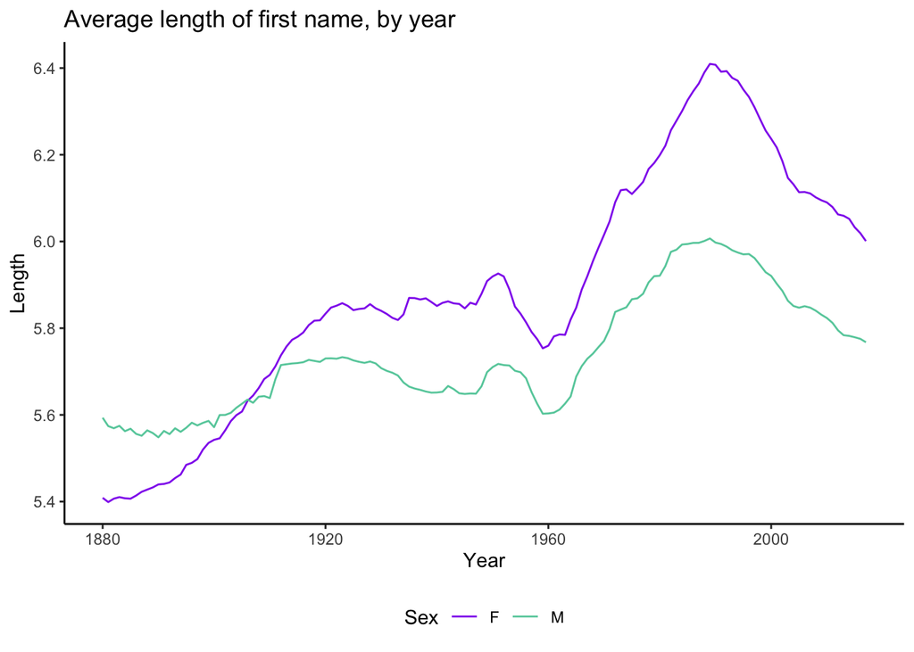

The plots look fairly similar for both sexes. There appears to be a general increase in the average length in a name, peaking around the 1990s.

Next, we plot the average number of vowels in the names of all babies, again separated by sex:

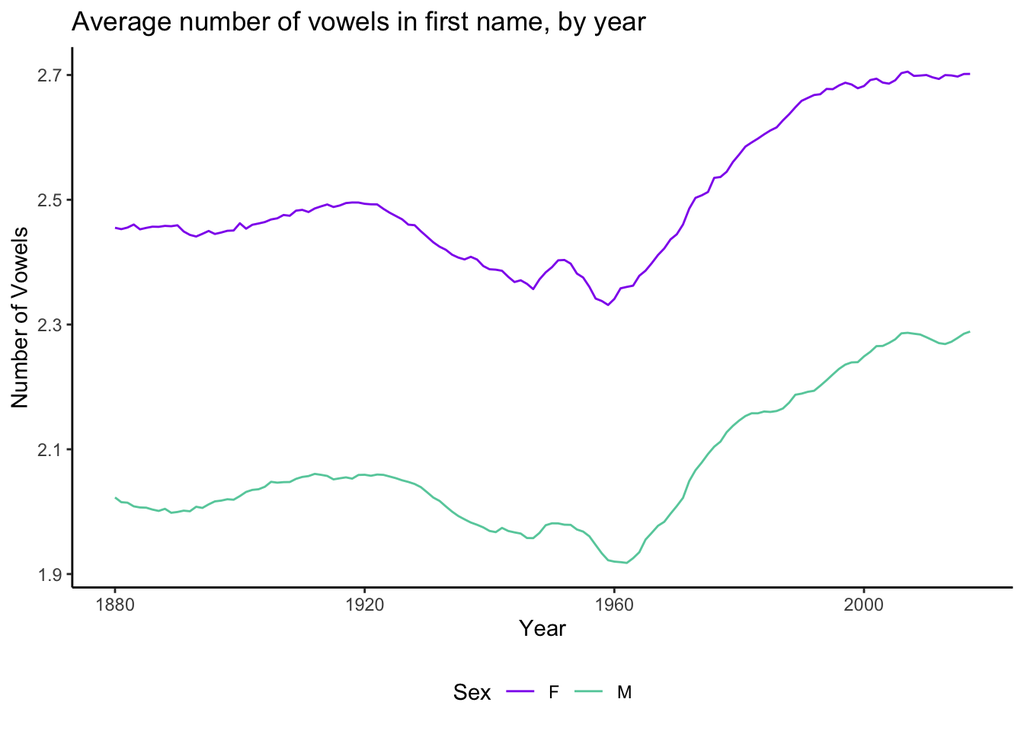

Here, the overall shape of the time series looks very similar for male and female babies. There might be an overall slight increase from 1880 to 2017, but there also appears to be a decrease around the 1960s. It is also worth noting that this plot is markedly different from the previous one. You might have initially expected that the average number of vowels would look similar to the average length of a name, since longer names likely require more vowels. However, this is not the case.

Next, we plot the average longest consonant run in the names of all babies, again separated by sex:

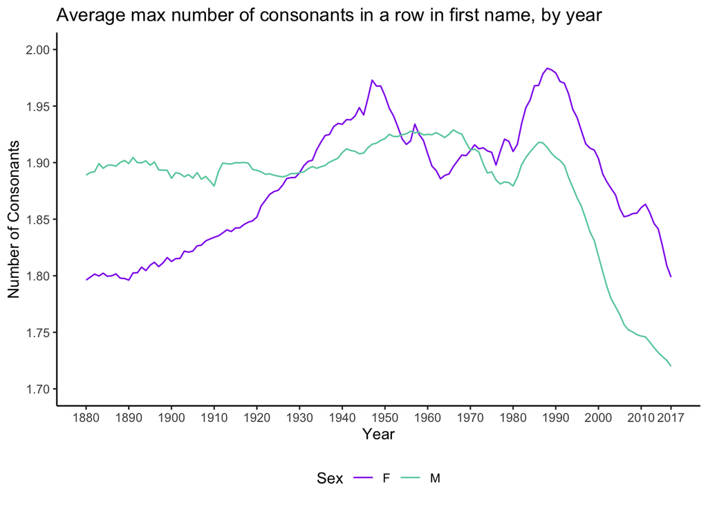

For both sexes, there appears to be a dramatic decrease in the average longest consonant run starting in the 1990s. Prior to that, there appears to be a slight increase for female babies while the values for male babies stay fairly constant. The peak here appears to be around the same time as the peak for average length, which makes sense since shorter names also means shorter runs of consonants. However, the graphs are still fairly different.

Calculating these values and plotting them required some additional sources, including documentation for the `stringr` and `ggplot2` packages and a couple chatGPT queries<sup>[4–7]</sup>.

# Modeling

## Average Longest Run of Consonants

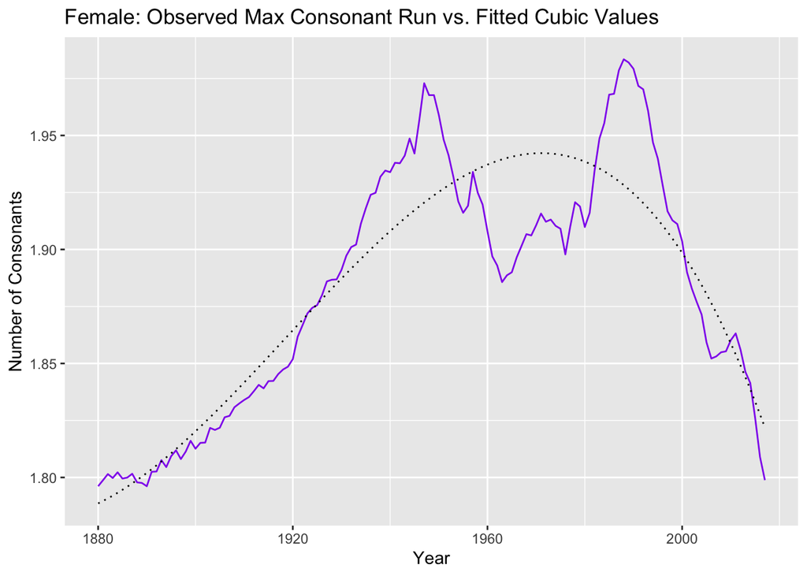

Next, we can plot the ACF of the residuals:

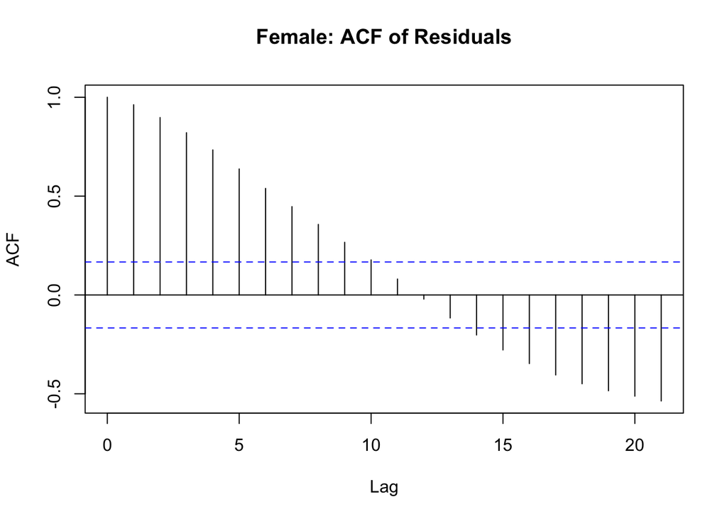

```r
resid_female <- residuals(lm_trend_female)
acf(resid_female, main  = "Female: ACF of Residuals")
```

This appears to exhibit some seasonality. However, since our data is annual data and not monthly or quarterly, we thought fitting a SARMA model would be an poor choice. There is no reason for naming patterns to exhibit seasonality.

AIC Table for Detrended Female Max Consonant Run Data

|  | MA0 | MA1 | MA2 | MA3 | MA4 | MA5 |
| --- | --- | --- | --- | --- | --- | --- |
| AR0 | -636.9663 | -793.5698 | -880.9617 | -944.4379 | -966.6744 | -989.191 |
| AR1 | -1005.3556 | -1026.3617 | -1027.1444 | -1028.6102 | -1028.6497 | -1034.389 |
| AR2 | -1032.6775 | -1034.8926 | -1042.6991 | -1032.7871 | -1031.3053 | -1032.512 |
| AR3 | -1032.2641 | -1042.9623 | -1040.9765 | -1038.8217 | -1037.5865 | -1030.522 |
| AR4 | -1034.1478 | -1032.8214 | -1039.5211 | -1037.8585 | NA | -1028.567 |
| AR5 | -1032.7562 | -1030.8427 | -1037.8649 | -1044.7639 | NA | NA |

In this particular case, the NAs are generated by a convergence warning. As a result, we will avoid $p, q \geq 4$. The table suggests that the best model is an $ARMA(3,1)$ model. However, if we plot the inverse roots of this model, we notice that some of the roots are on the border of the unit circle:

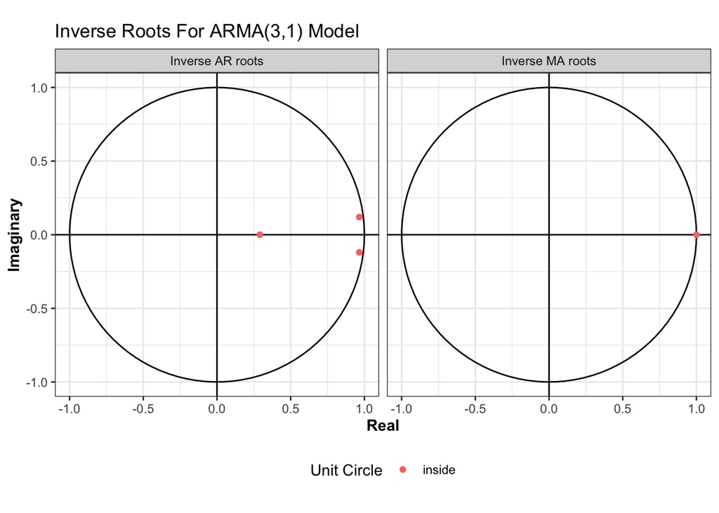

The same is true for an $ARMA(2,2)$ model. However, if we try an $ARMA(2,1)$ model, which also had a fairly small AIC, we no longer have this issue:

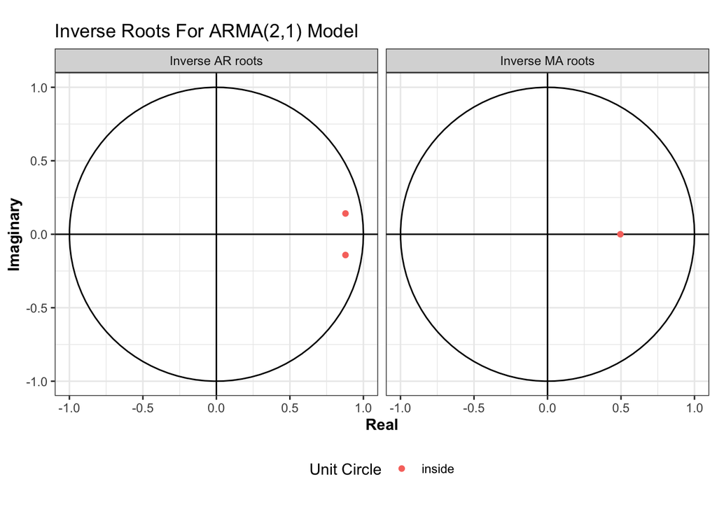

Interestingly, an $ARMA(2,1)$ model is also what the `auto.arima` model from the `forecast` package<sup>[10]</sup> suggests. Given that this model does not have the invertibility problems of models with larger $p$ and $q$, we will choose this $ARMA(2,1)$ model fit to the residuals of a cubic polynomial as our final model.

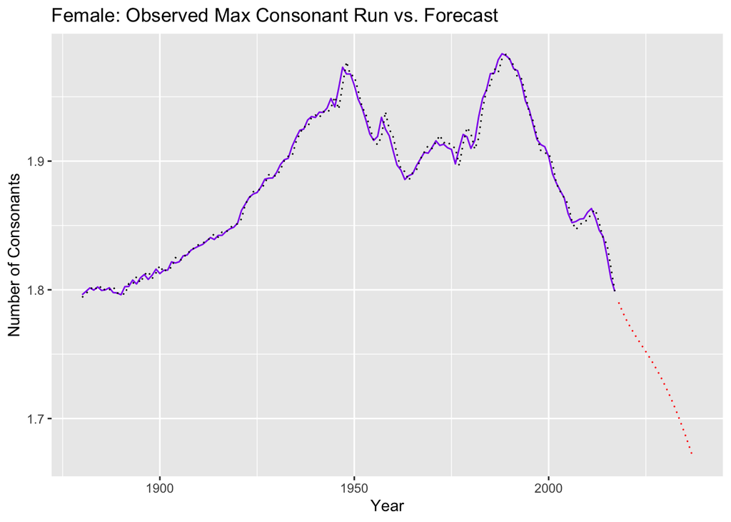

The 20 year forecast shows a dramatic decrease in the average longest consonant run of female baby names. This is likely because our model is unable to extrapolate well, which is not surprising.

The cubic fit to de-trend the data indicates a large drop past 2017. However, it is unlikely that this downward trend will continue for 20 years. We suspect that the average max consonant run might exhibit cyclical behavior beyond what we are able to observe with these 138 data points.

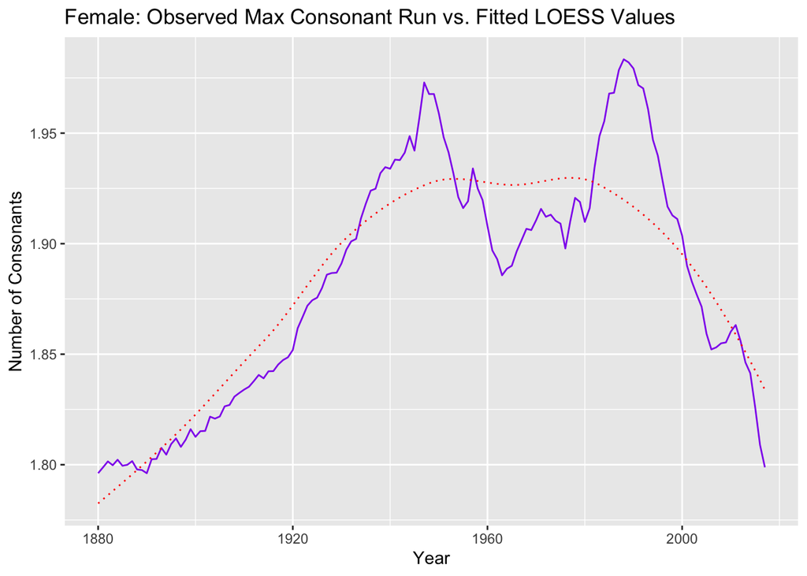

Ultimately, we need more years of data to be able to say anything concrete about how the average longest consonant run in female baby names changes. It’s interesting that both of our de-trending options treated the two separate peaks and the valley between them as noise, which would suggest a time series that only has one peak in 138 years, which might indeed be what’s happening.

Next, we will look at fitting a model to the average max consonant run in male baby names. We start by fitting both a cubic estimator to detrend our data.

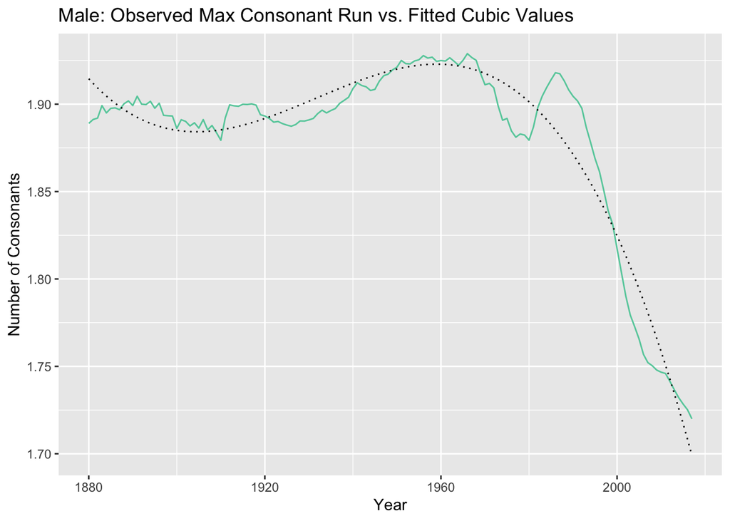

Next, we fit an ARMA model to the residuals generated from this cubic polynomial.

|  | MA0 | MA1 | MA2 | MA3 | MA4 | MA5 |
| --- | --- | --- | --- | --- | --- | --- |
| AR0 | -778.5777 | -940.7923 | -1006.910 | -1069.421 | -1095.604 | -1118.239 |
| AR1 | -1111.9092 | -1131.6017 | -1134.175 | -1147.533 | -1145.713 | -1157.511 |
| AR2 | -1142.3752 | -1126.3538 | -1171.314 | -1171.287 | -1171.654 | -1170.959 |
| AR3 | -1151.5376 | -1144.3317 | -1177.526 | -1178.143 | -1176.143 | -1174.173 |
| AR4 | -1166.6604 | -1163.6115 | -1178.038 | -1176.143 | -1175.728 | -1181.855 |
| AR5 | -1165.7344 | -1169.2923 | -1176.112 | -1175.786 | -1182.608 | -1180.930 |

The AIC table suggests an ARMA(5,4) model, so we look at the inverse roots of that model:

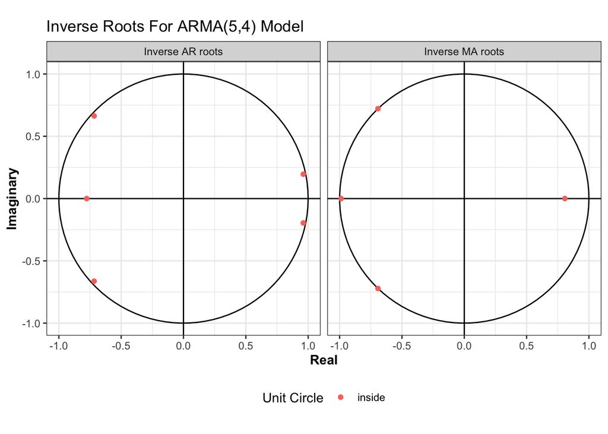

This includes many MA and AR roots right on the border, so this is probably not the best model. We investigated more of these plots for various combinations, and settled on an $ARMA(4,0)$ model, where the roots are not on the border of invertibility:

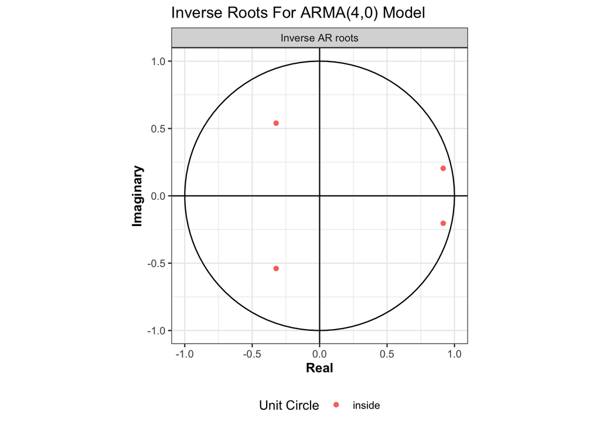

This looks much better, so we choose ARMA(4,0) fit to the residuals of a cubic polynomial as our best model. The plot below shoes the original data (in teal) with the fitted values (dotted black) and a forecast for the next 20 years (dotted red).

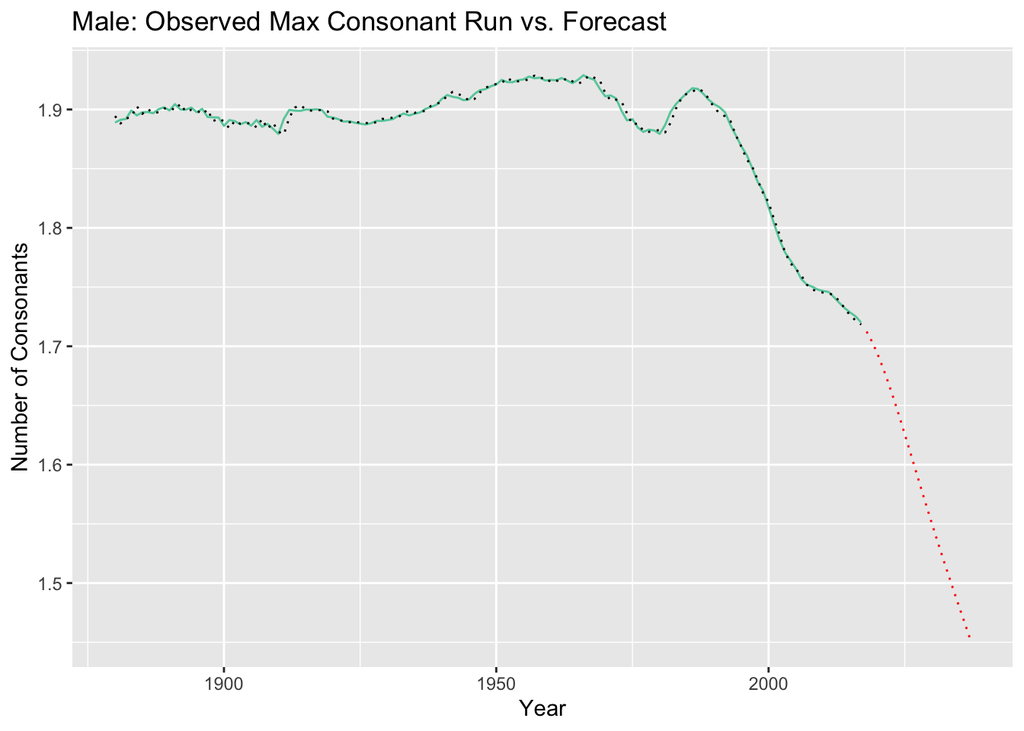

Like the forecasting for the female names, these predict that the average longest number of consonants in a row will continue to decrease. This is likely because of the cubic fit to the data indicates a decrease. In general, forecasting the average longest number of consonants is likely not a reliable thing to forecast. We include these forecasts for exploratory purposes, but caution that they should not be considered accurate.

Ultimately, both of our analyses for the average maximum consonant run indicate a single peak occurring around the 1970s. We suspect the current downward trend will have to plateau or turn around eventually, but do not have data to back this up. In particular, we suspect that trends around the number of consonants occurring in a row might have a cyclical pattern not observable in the data set we have. There do not appear to be cycles of smaller frequencies.

# Discussion

## Limitations

Despite having data from 1880 to 2017, we likely needed more data points. We suspect that cycles of naming behavior may be very, very long as naming patterns change slowly. It might have also been useful to see if additional covariates, such as other data points on linguistic behaviors and demographics of babies being born, would have helped us build a better model.

# Scholarship

We chose a very different subject for our project than previous projects. Many past projects focused on economic or environmental data. We took a different route and chose to look at a more socially-motivated time series. This may have contributed to some of our difficulties, as data occurring naturally in the environment or in financial markets generally follows more understandable patterns. It also might change more rapidly, where changes in naming patterns occur very slowly. We also chose to look at multiple related time series rather than a single one. Our goal in doing so was to address the “complexity” of names without having to choose a single definition for “complexity”. We also thought it would be interesting to compare the results of the different time series. In this sense, our project approaches our research question in a different way than most of the previous ones that set out to answer a single question about a single time series. While we believe our choice led to a more interesting project, it did mean that we had less time to devote to model fitting and diagnostics.

Like many of the past projects, we primarily used ARMA models and looked at `AIC` tables to determine the best model. We got the idea to look at the invertibility of the roots visually using the plot functionality available in `arima` and `arima2` from one of the past projects<sup>[11]</sup>. Unlike many of the projects, we fit a polynomial trend to detrend our data before using ARMA methods. We observed this in one other project<sup>[12]</sup>, and found one other that used LOESS smoothing<sup>[13]</sup>, but it did not seem to be a common choice. However, for our data it was necessary. We also did some forecasting, which did not appear in many of the past projects. Ultimately, this was not very useful. We suspect that our dataset does not extrapolate well, but it was interesting to see what it predicted.

Futhermore, we used `arima2` for some of our models where most midterm projects in the past just used `arima`. This likely did not matter in our analysis, but is a useful example of how `arima2` can be used successfully and fairly seamlessly in time series analysis. We did have to use `arima` models for the forecasting but we used `arima2` for the modeling process of the longest consonant run time series. Other than the forecasting, there were no points where `arima2` was more difficult to use than `arima`, and we may have avoided optimization issues.

# Contributions

Jaylin came up with the idea to use the `babynames` data set, found the article that inspired our idea to look at average length and average number of vowels, and came up with the idea to took at the longest number of consonants in a row. She wrote the code to create the six time series we looked at. She wrote the introduction, the exploratory data analysis section, the scholarship section and the section on the average longest run of consonants. She also set up the bibliography.

**References**.

1. *Have We Reached Peak Baby Name? - The New York Times*. (n.d.). Retrieved February 16, 2025, from https://www.nytimes.com/2024/06/15/style/baby-name-meme-tiktok.html

2. Wickham, H. (2021). *Babynames: US baby names 1880-2017*. https://CRAN.R-project.org/package=babynames

3. Baby names and culture. (2020). In *Joshua Ashkinaze*. https://www.joshash.space/data-science/names-analysis

4. Wickham, H. (2023). *Stringr: Simple, consistent wrappers for common string operations*. https://CRAN.R-project.org/package=stringr

5. OpenAI. (2025). *chatGPT. Note: chatGPT was asked "what’s the easiest way to count the number of vowels in a string". This was used to calculate the average number of vowels in a name.* https://chatgpt.com/

6. OpenAI. (2025). *chatGPT. Note: chatGPT was asked "what’s the easiest way to get the longest run of consonants in a string". The given answer was not particularly useful, but motivated the use of ‘sapply‘ and ‘str_split‘ which was how the longest consonant run was ultimately calculated.* https://chatgpt.com/

7. Wickham, H. (2016). *ggplot2: Elegant graphics for data analysis*. Springer-Verlag New York. https://ggplot2.tidyverse.org

8. Ionides, E. (2025). *Notes for STATS/DATASCI 531, Modeling and Analysis of Time Series Data*. https://ionides.github.io/531w25/

9. Wheeler, J., McAllister, N., & Sylvertooth, D. (2024). *arima2: Likelihood based inference for ARIMA modeling*. https://CRAN.R-project.org/package=arima2

10. Hyndman, R. J., & Khandakar, Y. (2008). Automatic time series forecasting: The forecast package for R. *Journal of Statistical Software*, *27*(3), 1–22. https://doi.org/10.18637/jss.v027.i03

11. Anonymous. (n.d.). Midterm project: Analysis of BTC and DOGE. *STATS 531 Winter 2024*. https://ionides.github.io/531w24/midterm_project/project02/blinded.html

12. Anonymous. (n.d.). Investigating trends in household electricity consumption. *STATS 531 Winter 2024*. https://ionides.github.io/531w24/midterm_project/project12/blinded.html

13. Anonymous. (n.d.). Statistical modeling and analysis of california wildfires time series. *STATS 531 Winter 2022*. https://ionides.github.io/531w22/midterm_project/project16/blinded.html